# 36-315 Homework 03, Fall 2021

SOLUTIONS

Due Tuesday, September 21 (11:59pm) on Gradescope

## Homework 03: Visualizations and Inference for 2D Categorical Data

*General instructions for all assignments*:

- Use this file as the template for your submission. Be sure to write your name at the top of this page in the author section.
- When writing out answers to questions, please delete unnecessary text (e.g. this text, the problem statements, etc). That said, keep the nicely formatted “Problem 1”, “Problem 2”, “a.”, “b.”, etc. If you prefer to keep the problem statements, then you must write out your answers in *italics* or **bold** to differentiate your answers from the problem statements.
- For your homework submission, generate an .html file and an .Rmd file (named as: [AndrewID]-315-Homework03.Rmd – e.g. “zbranson-315-Homework03.Rmd”). When you’re done, submit it to Gradescope (the link to the course’s Gradescope can be found on Canvas). Gradescope only accepts PDFs, so take a moment to convert your .html file to a PDF using [pdfcrowd.com](https://pdfcrowd.com/), [this converter](https://document.online-convert.com/convert/html-to-pdf), or a similar converter. You can get RStudio to generate PDFs for you, but it requires some extra work—see the syllabus.
- Your file should contain the code to answer each question in its own code block. Your code should produce plots/output that will be automatically embedded in the output (.html) file.
- Each answer must be supported by written statements (unless otherwise specified). **Thus, even if you think your code output is self-explanatory, be sure to answer questions with written statements outside of code blocks.**
- Although it’s okay to discuss homework problems with other students, all of your homework (code, written answers, etc.) should be only your own. Instances of identical, nearly identical, or copied homework will be considered cheating and plagiarism. In other words, you must follow rules of academic integrity (as detailed in the syllabus).

# Problem 1: Data Manipulation and The Many Ways To Create 1D and 2D Bar Charts (38 points)

This problem uses the IMDb ratings data from Lab02. The following code reads in the data and creates several new variables. (This same code was used in Lab2.)

```r
library(tidyverse)

# reads Matey's IMDb rated movies TV Series, etc.
mateys_imdb <- read.csv("https://raw.githubusercontent.com/zjbranson/315Fall2021/master/imdb_ratings.csv")

# filters only Featured Films
mateys_movies <- mateys_imdb %>% filter(Title.type == "Feature Film")

mateys_movies <- mutate(mateys_movies,
                    vote_date = as.Date(mateys_movies$created,
                                format = "%a %b %d %H:%M:%S %Y"),
                    day_of_week = weekdays(vote_date),
                    weekend = ifelse(day_of_week %in% c("Saturday", "Sunday"),
                                     "Weekend", "Workday"),
                    duration = cut(Runtime..mins., c(0, 90, 120, Inf),
                                        labels = c("Short", "Medium", "Long")),
                    ratings = cut(You.rated, c(0, 4, 7, Inf),
                                  labels = c("Low", "Med", "High")),
                    movie_period = cut(Year, c(0, 1980, 2000, 2018),
                              labels = c("Old", "Recent", "New"))
)
```

1. (3pts) In the above code we used the `mutate()` function to create several new columns in the `mateys_movies` dataset. In a similar vein, write code here that creates two new columns:
- `popular`: “Popular” if the number of votes (`Num..Votes`) received by the movie is greater than average (i.e., greater the mean `Num..Votes`), and “Not Popular” otherwise.
- `wednesday`: “Yes” if Matey voted on Wednesday, and “No” otherwise.

**Hint**: Look at the function `ifelse` (similar to what you had to do in Lab1).

*Here we create the two new columns `popular` and `wednesday`:*

```r
mateys_movies <- mutate(mateys_movies,
                    # new variables:
                    popular = ifelse(Num..Votes < mean(Num..Votes),
                              "Not Popular", "Popular"),
                    wednesday = ifelse(day_of_week == "Wednesday", "Yes", "No"))
```

2. (3pts) We could create a bar plot of `day_of_week` using the standard approach with `ggplot() + geom_bar()`; however, with large datasets like this one, it can take a small amount of time to do the calculations necessary to create the bar chart. This is because `geom_bar()` tabulates the counts in each category when the line of code is run. For large datasets, it’s better to store the counts ahead of time and then reference these when creating the bar plot, as we did in Lab2 with `duration_marginal`.

Here, create a bar plot showing the distribution of `day_of_week` (at the count scale), but calculate the marginal distribution ahead of time (i.e., use an approach similar to Lab2, but on the **count** scale instead of the percentage scale).

*Here is our code for the bar plot:*

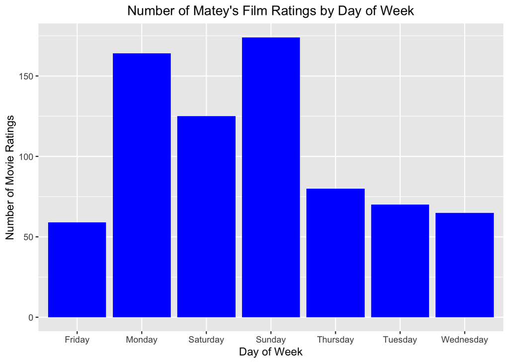

```r
#compute the marginal distribution
day_counts <- mateys_movies %>%
  group_by(day_of_week) %>%
  summarize(count = n())
#now make the plot
ggplot(day_counts, aes(x = day_of_week, y = count)) +
  geom_bar(stat = "identity", fill = "blue") +
  labs(title = "Number of Matey's Film Ratings by Day of Week",
       x = "Day of Week", y = "Number of Movie Ratings") +
  theme(plot.title = element_text(hjust = 0.5))
```

3. (3pts) The same computational issues discussed in Part B apply to 2D bar plots too; but first, build a stacked bar chart of `day_of_week` (x-axis) and `popular` (fill), in the standard way (using `... + geom_bar()`).

*Here is the “standard” approach for creating a stacked bar plot with `day_of_week` on the x-axis and `popular` denoting the colors (using the `fill` argument):*

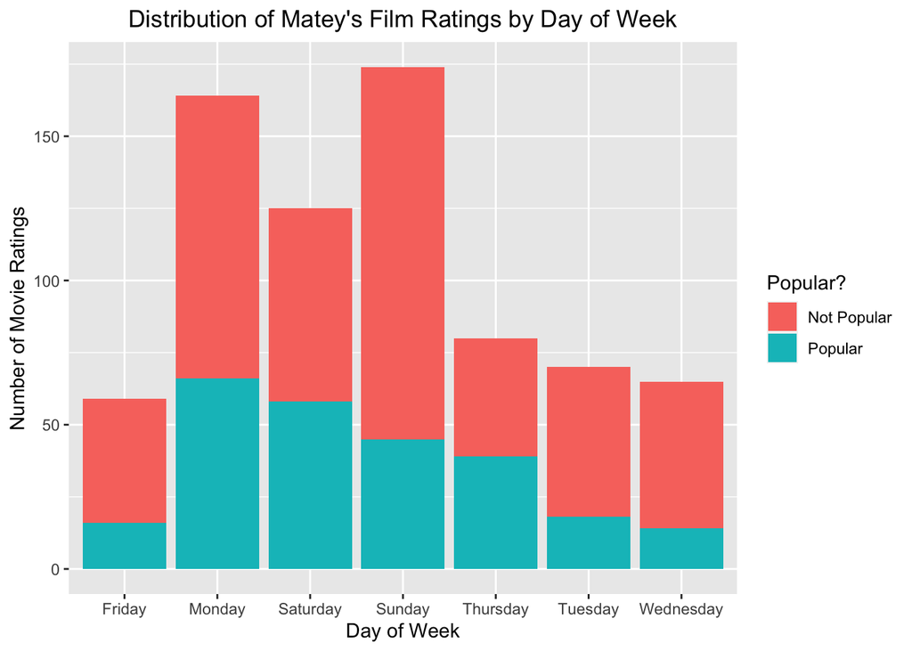

```r
ggplot(mateys_movies, aes(x = day_of_week, fill = popular)) +
  geom_bar(stat = "count") +
  labs(x = "Day of Week", y = "Number of Movie Ratings",
       title = "Distribution of Matey's Film Ratings by Day of Week") +
  scale_fill_discrete(guide = guide_legend(title = "Popular?")) +
  theme(plot.title = element_text(hjust = 0.5))
```

4. (3pts) Next, use the following approach to build the same graph (all you have to do is uncomment the code and add titles/labels):

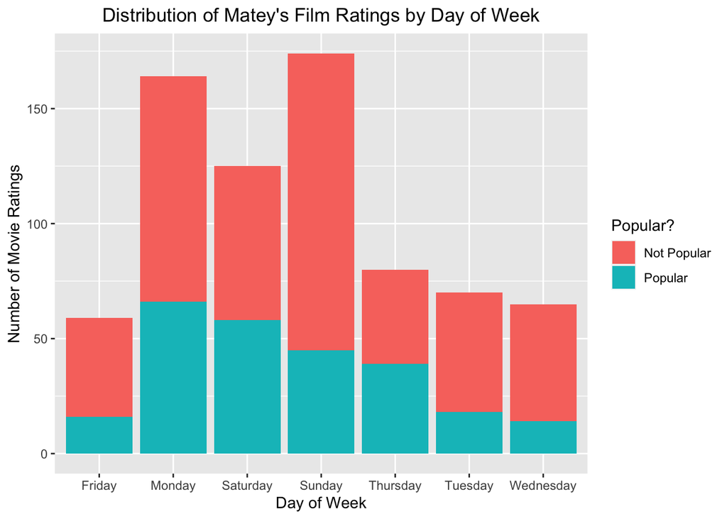

```r
library(tidyverse)
days_popular <- mateys_movies %>%
  group_by(day_of_week, popular) %>%
  summarize(count = n())

ggplot(days_popular, aes(x = day_of_week, y = count, fill = popular)) +
  geom_bar(stat = "identity") +   labs(x = "Day of Week", y = "Number of Movie Ratings",
       title = "Distribution of Matey's Film Ratings by Day of Week") +
  scale_fill_discrete(guide = guide_legend(title = "Popular?")) +
  theme(plot.title = element_text(hjust = 0.5))
```

Compare the above code to the code you wrote in Part C. Answer the following questions:

- Why do we use `stat = "identity"` in the above code?

*We use `stat = "identity"` when counts are already calculated; the `count` variable is assigned to the y-axis aesthetic, and identity will use that variable to draw the bars of the bar chart at the appropriate/corresponding heights.*

- What is the default `stat` in `geom_bar()` (i.e., what is used by default in Part C)?

*`stat = "count"` is the default, which takes the full dataset and counts the number of observations in each category of the variable assigned to the x-aesthetic (in this case, `day_of_week`).*

5. (3pts) As we discussed in class, another way to visualize two categorical variables is with a side-by-side bar chart. For this part, create a side-by-side bar plot of `day_of_week` by copying-and-pasting your Part C or Part D code (either is fine) and adding `position = "dodge"` in `geom_bar()`.

*Here’s the code for the side-by-side bar plot:*

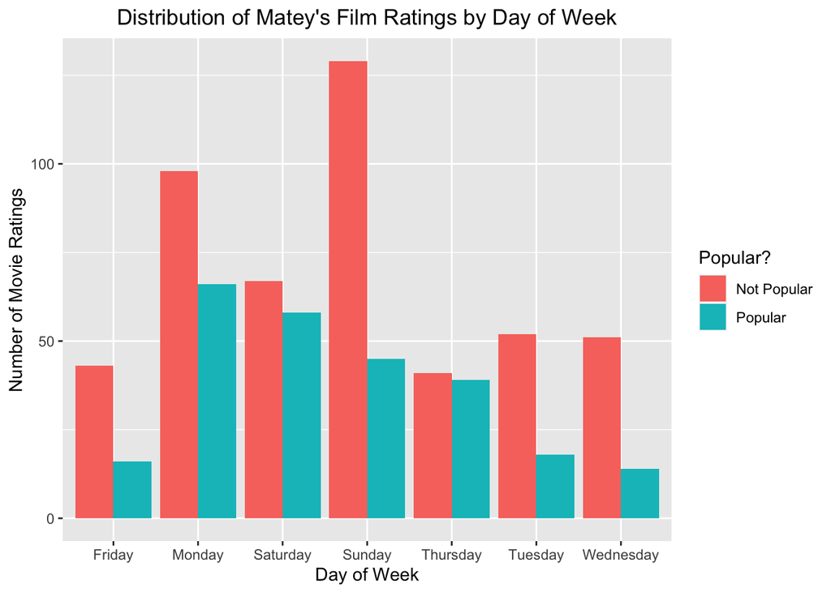

```r
library(tidyverse)
days_popular <- mateys_movies %>%
  group_by(day_of_week, popular) %>%
  summarize(count = n())

ggplot(days_popular, aes(x = day_of_week, y = count, fill = popular)) +
  geom_bar(stat = "identity", position = "dodge") +   labs(x = "Day of Week", y = "Number of Movie Ratings",
       title = "Distribution of Matey's Film Ratings by Day of Week") +
  scale_fill_discrete(guide = guide_legend(title = "Popular?")) +
  theme(plot.title = element_text(hjust = 0.5))
```

6. (3pts) Another way to visualize two categorical variables is with a “proportional” bar plot. For this part, create a proportional bar plot by copying-and-pasting your Part E code, and then change `position = "dodge"` (which places the bars side-by-side) to `position = "fill"` (which will fix the heights of the bars to all be 1, and fill them proportionally according to the second variable). Be sure to change your y-axis label to something appropriate.

*Here is the code for the proportional bar plot:*

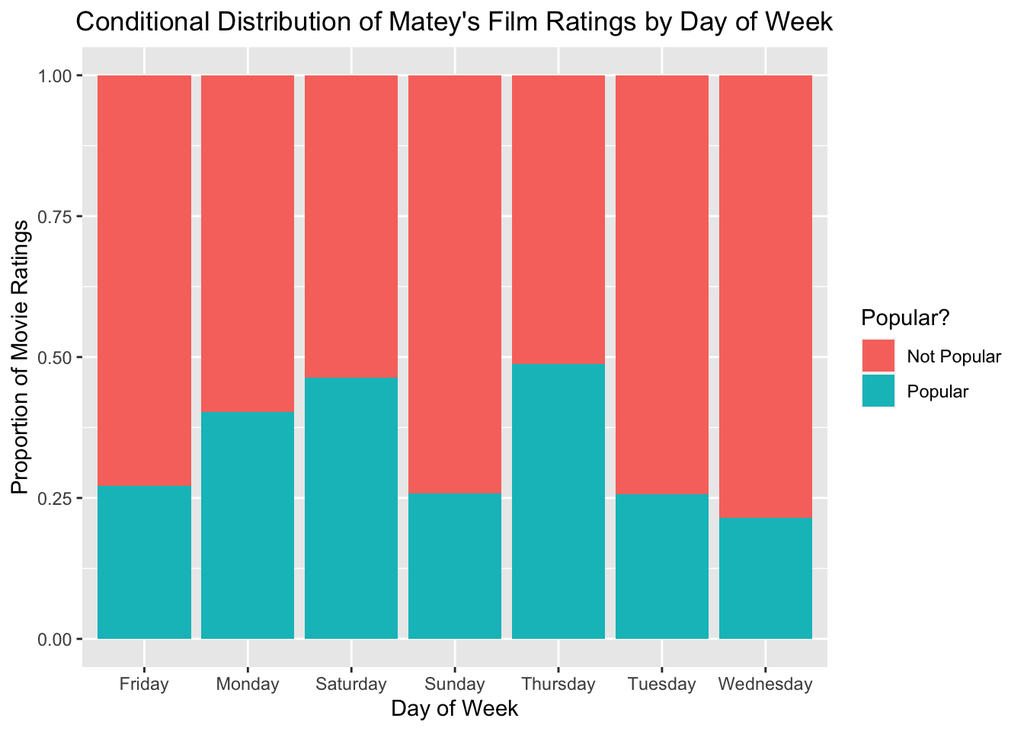

```r
library(tidyverse)
days_popular <- mateys_movies %>%
  group_by(day_of_week, popular) %>%
  summarize(count = n())

ggplot(days_popular, aes(x = day_of_week, y = count, fill = popular)) +
  geom_bar(stat = "identity", position = "fill") + labs(x = "Day of Week", y = "Proportion of Movie Ratings",
       title = "Conditional Distribution of Matey's Film Ratings by Day of Week") +
  scale_fill_discrete(guide = guide_legend(title = "Popular?")) +
  theme(plot.title = element_text(hjust = 0.5))
```

7. (3pts) Although it’s not necessarily the case here, sometimes it can be difficult to read the category names on the x-axis if they are long and overlap. In these cases, it can be helpful to rotate the x-axis labels. Search the Internet for an approach for rotating the x-axis labels in `ggplot()`. Pick one of the graphs in Part C, D, E, or F, and rotate the labels in the graph by 45 degrees. Include the code and graph for that new plot here.

*Below is the code (and plot) for rotating the x-axis labels from Part C. Note that we used `axis.text.x = element_text(angle = 45, hjust = 1)` within `theme()` to rotate the x-axis labels.*

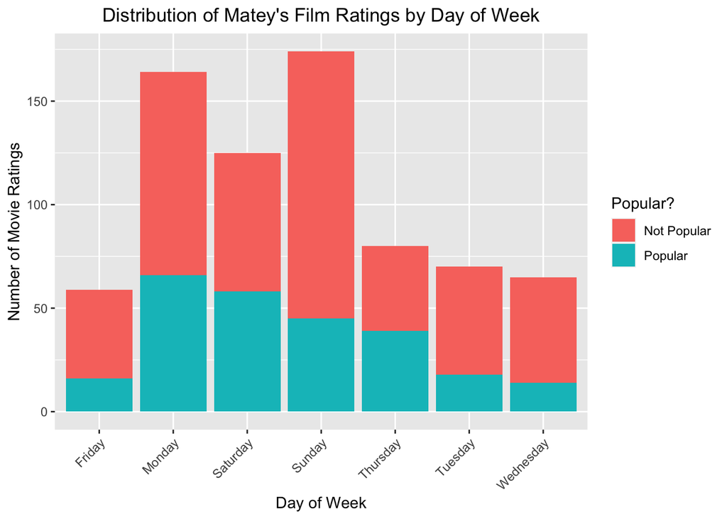

```r
ggplot(mateys_movies, aes(x = day_of_week, fill = popular)) +
  geom_bar(stat = "count") +
  labs(x = "Day of Week", y = "Number of Movie Ratings",
       title = "Distribution of Matey's Film Ratings by Day of Week") +
  scale_fill_discrete(guide = guide_legend(title = "Popular?"))  +
  theme(axis.text.x = element_text(angle = 45, hjust = 1),
        plot.title = element_text(hjust = 0.5))
```

8. (12pts) In the above, we have gone through different ways to visualize two categorical variables, `day_of_week` and `popular`. Consider four different distributions:
- The marginal distribution of `day_of_week`.

*I prefer the graph in Part D; it’s easy to just look at the height of the bars (ignoring color) to assess the marginal distribution of `day_of_week`. We can see that Matey tended to rate movies pretty frequently Saturday-Monday (with Sunday being the most frequent), whereas Tuesday-Friday were much less frequent (with Friday being the least frequent).*

- The marginal distribution of `popular`.

*I again prefer the graph in Part D; although it’s more difficult to assess the marginal distribution of `popular` (compared to the marginal distribution of `day_of_week`), by comparing the total blue color to the total red color, we can still see that about one-third of movies were considered “Popular,” whereas the other two-thirds of movies were considered “Not Popular.” I found it a bit easier to add these colors than the colors in the Part E plot. Meanwhile, note that it’s difficult to use the Part F plot to assess the marginal distribution of `popular`: Even though the marginal distribution of `popular` is characterized by two proportions (which may make you think that a proportional bar plot would be helpful), some days are more common than others, and thus the seven different proportions displayed in Part F should be given unequal weight when considering the marginal distribution of `popular`.*

- The conditional distribution of `day_of_week` given `popular`.

*I prefer the graph in Part E; by focusing on just the red bars or just the blue bars, I can easily see what the conditional distribution is for `day_of_week` given either value of `popular`. In terms of most and least common days, the conditional distribution for either value of `popular` seems pretty simiar: Saturday-Monday are the most frequent, and Tuesday-Friday are less frequent. However, the differences are much more pronounced for “Not Popular” movies: “Not Popular” movies are much more frequent Saturday-Monday than Tuesday-Friday, whereas “Popular” movies are only somewhat more frequent Saturday-Monday than Tuesday-Friday.*

For each of the four distributions, do the following two things:

1. Write whether you think the graph from Part D, E or F is the best graph to display that distribution, with a one-sentence explanation as to why.
2. Using the graph you picked, describe the distribution in 1-3 sentences.

**In your answer for this question, just keep the above bulleted list, and put your answer (graph, explanation, and description) next to each bullet.**

1. (5pts) Now, write out (in numbers) the conditional distribution of `day_of_week` given `popular`, i.e., the distribution of `day_of_week` for each value of `popular`. In your answer, please include the code you used to figure this out. A few hints for this question:
- If I asked you to write out the marginal distribution of `day_of_week`, you would report back 7 proportions that add up to 1 (corresponding to the estimated probabilities of a movie rating being on each day of the week).
- The conditional distribution I’m asking for is a function of `popular`, which is a binary variable. In other words, your answer should communicate something like, “If a movie is popular, then the distribution of `day_of_week` is” followed by 7 proportions that add up to 1. Similarly, you should communicate what the proportions are when the movie is not popular. (Thus, your final answer should have 2 sets of 7 proportions; you only need to include these 2 sets of 7 proportions in your answer.)
- The `subset()` function might be helpful here; this function takes in a dataset and returns the subset of the dataset that fulfills certain criteria (e.g., a dataset only containing movies that are popular). See the help documentation for this function for details. Alternatively, you can also use the `prop.table()` function.

*One efficient way to answer this question is to use the `prop.table()` function:*

```r
prop.table(table(mateys_movies$popular, mateys_movies$day_of_week), margin = 1)
```

```
##
##                   Friday     Monday   Saturday     Sunday   Thursday    Tuesday
##   Not Popular 0.08939709 0.20374220 0.13929314 0.26819127 0.08523909 0.10810811
##   Popular     0.06250000 0.25781250 0.22656250 0.17578125 0.15234375 0.07031250
##
##                Wednesday
##   Not Popular 0.10602911
##   Popular     0.05468750
```

*By setting `margin = 1`, we see that the top row displays the condititional distribution of `day_of_week` given “Not Popular”, and the bottom row does the same for “Popular.” We know these are indeed the conditional distributions in part because the proportions add up to 1 in each row.*

*Alternatively, we could compare these vectors manually, using the following code:*

```r
#subset of the data with popular movies
popularData = subset(mateys_movies, popular == "Popular")
#subset of the data with unpopular movies
unpopularData = subset(mateys_movies, popular == "Not Popular")

#distribution of day_of_week
#conditional on Popular
table(popularData$day_of_week)/nrow(popularData)
```

```
##
##    Friday    Monday  Saturday    Sunday  Thursday   Tuesday Wednesday
## 0.0625000 0.2578125 0.2265625 0.1757812 0.1523438 0.0703125 0.0546875
```

```r
#distribution of day_of_week
#conditional on Not Popular
table(unpopularData$day_of_week)/nrow(unpopularData)
```

```
##
##     Friday     Monday   Saturday     Sunday   Thursday    Tuesday  Wednesday
## 0.08939709 0.20374220 0.13929314 0.26819127 0.08523909 0.10810811 0.10602911
```

*The above code computes what the estimated probability of each day given `popular` (i.e., the conditional distribution). As stated in the comments of the code, the first set of seven numbers corresponds to the conditional distribution of `day_of_week` given that a movie is “Popular;” likewise, the second set of seven numbers corresponds to the conditional distribution of `day_of_week` given that a movie is “Not Popular.” From this alone we can’t see if there is a statistically significant difference between these two sets of numbers, but we can at least observe that (as we’ve commented previously), across both values of `popular`, Saturday-Monday are the most frequent, and Tuesday-Friday are less frequent.*

# Problem 2: A Mosaic of Songs (37 points)

In this homework, we will work with the Guardian’s list of [1000 Songs to Hear Before You Die.](https://www.theguardian.com/news/datablog/2009/mar/20/1) The data is available [here](https://raw.githubusercontent.com/zjbranson/315Fall2021/master/1000songs.csv).

1. (3pts) Write `R` code to read in the data from the link above; define the dataset as `songs`. (If you’re unsure how to do this, go back to any of the previous labs or homeworks to see how I read in data using a URL.) How many rows does the dataset have, and what are the names of the variables? For this part, you just need to write code that answers these questions; you don’t need to write anything outside of your code for this part.

(**Hint**: Very technically, this is *not* the list of 1000 songs to hear before you die—I’m not sure where some of the songs went.)

*The code below reads in the dataset, and then prints out the number of rows and column names of the dataset.*

```r
#read in the data
songs = read.csv("https://raw.githubusercontent.com/zjbranson/315Fall2021/master/1000songs.csv")
#number of rows
nrow(songs)
```

```
## [1] 994
```

```r
#column names
names(songs)
```

```
## [1] "THEME"       "TITLE"       "ARTIST"      "YEAR"        "SPOTIFY_URL"
```

2. (2pts) Now we’re going to recreate the mosaic plot on the [Wikipedia page for mosaic plots](https://en.wikipedia.org/wiki/Mosaic_plot) (which Professor Branson also made in class). This plot involves *decades*, rather than individual years. In other words, we need to categorize the `YEAR` variable into `decades`.

The `YEAR` variable denotes individual years (e.g., 1955, 2006, etc.) Thus, it is a quantitative variable. However, if you type `class(songs$YEAR)` in the Console, you should find that `R` has classified this variable as a `"factor"` or `"character"` (which is not the typical class for a quantitative variable). Why has `R` given `YEAR` this unintuitive class?

(**Hint**: In the Console, inspecting the `YEAR` variable should give you an idea of what’s happening.)

*If you look at the `YEAR` variable, you’ll find that some years are written with commas (e.g., “1,956”) and others are written without commas (e.g., “1956”). Numbers aren’t written with commas in `R`, and as a result, `R` treats instances like “1,956” as words, meaning that `R` treats `YEAR` as a categorical variable.*

*To further understand this, we can look at all the levels of `YEAR`:*

```r
levels(factor(songs$YEAR))
```

```
##   [1] "1,956.00" "1,961.00" "1,964.00" "1,965.00" "1,966.00" "1,967.00"
##   [7] "1,968.00" "1,969.00" "1,971.00" "1,972.00" "1,973.00" "1,974.00"
##  [13] "1,975.00" "1,977.00" "1,978.00" "1,979.00" "1,980.00" "1,983.00"
##  [19] "1,986.00" "1,989.00" "1,993.00" "1,994.00" "1916"     "1922"
##  [25] "1928"     "1929"     "1931"     "1932"     "1935"     "1936"
##  [31] "1938"     "1939"     "1940"     "1941"     "1944"     "1946"
##  [37] "1949"     "1950"     "1951"     "1952"     "1953"     "1954"
##  [43] "1955"     "1956"     "1957"     "1958"     "1959"     "1960"
##  [49] "1961"     "1962"     "1963"     "1964"     "1965"     "1966"
##  [55] "1967"     "1968"     "1969"     "1970"     "1971"     "1972"
##  [61] "1973"     "1974"     "1975"     "1976"     "1977"     "1978"
##  [67] "1979"     "1980"     "1981"     "1982"     "1983"     "1984"
##  [73] "1985"     "1986"     "1987"     "1988"     "1989"     "1990"
##  [79] "1991"     "1992"     "1993"     "1994"     "1995"     "1996"
##  [85] "1997"     "1998"     "1999"     "2,003.00" "2,004.00" "2,006.00"
##  [91] "2,007.00" "2,008.00" "2000"     "2001"     "2002"     "2003"
##  [97] "2004"     "2005"     "2006"     "2007"     "2008"
```

*This displays all the unique years in the dataset; we see that some years have commas and others do not.*

*As an aside: I didn’t code the `YEAR` variable this way just to be mean—this is what the data actually looked like when I downloaded it from [The Guardian here](https://www.theguardian.com/news/datablog/2009/mar/20/1). This problem is meant to demonstrate that you need to examine your data and see how it is recorded before jumping straight to visualizations.*

3. (6pts) Uncomment the code below to fix the issue discussed in Part B:

```r
songs$YEAR = as.numeric(gsub(",","",songs$YEAR))
```

Then, use the following code to define the `decade` variable and convert it to a `factor` (I thought about assigning you to write this code, but I decided to be kind):

```r
songs$decade = ifelse( songs$YEAR <= 1959, "1910s-50s",
 ifelse( songs$YEAR <= 1969, "1960s",
    ifelse( songs$YEAR <= 1979, "1970s",
        ifelse(songs$YEAR <= 1989, "1980s",
            ifelse(songs$YEAR <= 1999, "1990s", "2000s")))) )
 songs$decade = as.factor(songs$decade)
```

After you’ve done this, answer the following questions:

- Does it seem like any given song in this dataset is equally likely to come from each decade? (Here, 1910-1950s is considered “one” decade.) Answer this question using a statistical test.

*This question is essentially asking if the song proportions are equal across decades; this is exactly what the chi-squared test assesses. Here we run the chi-squared test on the decade variable:*

```r
chisq.test(table(songs$decade))
```

```
##
##  Chi-squared test for given probabilities
##
## data:  table(songs$decade)
## X-squared = 181, df = 5, p-value < 2.2e-16
```

*We see that the p-value is quite small (and certainly less than 0.05); thus, we reject the null hypothesis that the proportions are equal across decades, in favor of the alternative that they differ. In other words, we conclude that any given song in this dataset is not equally likely to come from each decade.*

- After you’ve answered the previous part: Are you surprised by what you found from the statistical test you just used, given the context of how this dataset was created? State “Yes, I am surprised” or “No, I am not surprised,” followed by a 1-2 sentence explanation as to why. In your answer, please also provide one piece of graphical or non-graphical EDA that supports why you are or are not surprised. (**Hint**: This list was compiled by writers at The Guardian—a British newspaper—in 2009. So, this list consists of songs that writers at The Guardian thought were “the best” in 2009.)

*No, I am not surprised - most of the writers for The Guardian during this time probably grew up in the 1960s and 1970s, and thus they may be more biased towards songs from those decades. Indeed, if we look at a contingency table of `decade`, we see that the 1960s and 1970s are the most common decades:*

```r
table(songs$decade)
```

```
##
## 1910s-50s     1960s     1970s     1980s     1990s     2000s
##        71       243       258       196       108       118
```

*Sure, it may be the case that these decades experienced the “best” songs, but I suspect that this list is biased by the age of the people who made this list.*

4. (10pts) Make two mosaic plots. For each plot, put `decade` as the column and `THEME` as the row. For the first plot, color the mosaic plot according to `THEME` (i.e., decades with the same theme should have the same color). For the second plot, color the mosaic plot according to Pearson residuals. No need to interpret the graphs (we did that in lecture). Instead, answer the following question: From the mosaic plots, are you able to easily assess the marginal distribution of `decade` or of `THEME`? If you say `decade`, create *another* plot (not a mosaic plot) that shows the marginal distribution of `THEME`. If you say `THEME`, create *another* plot (not a mosaic plot) that shows the marginal distribution of `decade`.

*Here are two mosaic plots, one colored by row and one colored by Pearson residuals:*

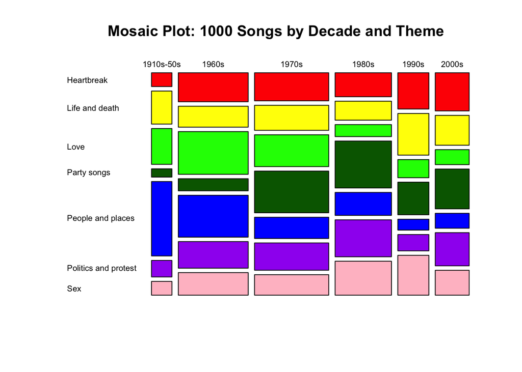

```r
#mosaic plot colored by THEME
mosaicplot(table(songs$decade, songs$THEME), main = "Mosaic Plot: 1000 Songs by Decade and Theme",
    color = c("red", "yellow", "green", "darkgreen", "blue", "purple", "pink"),
    las = 1)
```

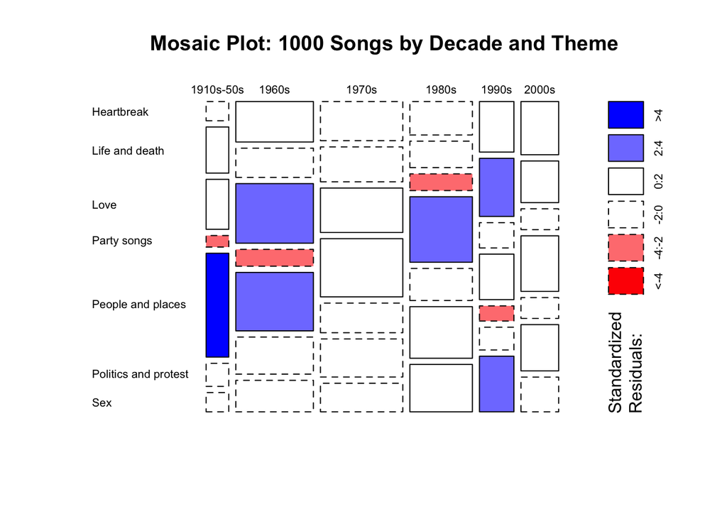

```r
#mosaic plot colored by pearson residuals
mosaicplot(table(songs$decade, songs$THEME), main = "Mosaic Plot: 1000 Songs by Decade and Theme", shade = TRUE, las = 1)
```

```r
#Note that in the above, I used the las argument to rotate the axis labels.
#This is a common argument to specify in base R plots.
```

*In mosaic plots, the width of the rectangles is proportional to a marginal distribution, and the height is proportional to a conditional distribution. Thus, from the above plots, we can easily assess the marginal distribution of `decade`. To assess the marginal distribution of `THEME`, here is a barplot:*

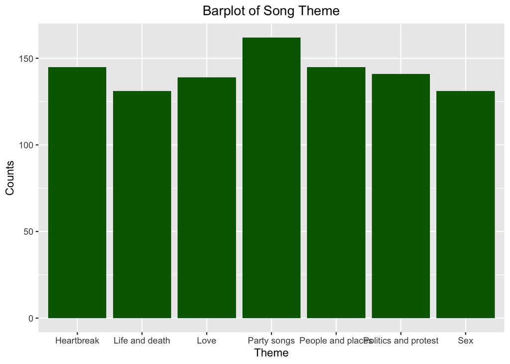

```r
library(ggplot2)
ggplot(data = songs, aes(x = THEME)) +
  geom_bar(fill = "darkgreen") +
  labs(title = "Barplot of Song Theme",
       x = "Theme",
       y = "Counts") +
  theme(plot.title = element_text(hjust = 0.5))
```

5. (4pts) [Professor D. Che](https://en.wikipedia.org/wiki/Damon_Che) comes up to you and makes two claims:
- There is an equal proportion of songs from each theme on this list.
- The decade of a song is independent of the theme of the song.

State whether you agree or disagree with each of these claims using statistical evidence. Please provide any code you used to run statistical tests.

*To assess if the proportions across themes are equal, we can run a chi-square test:*

```r
chisq.test(table(songs$THEME))
```

```
##
##  Chi-squared test for given probabilities
##
## data:  table(songs$THEME)
## X-squared = 4.7183, df = 6, p-value = 0.5804
```

*From this, we fail to reject the null hypothesis that the proportions are equal, and thus we don’t disagree (i.e., for all practical purposes, agree) with Professor Che’s first claim.*

*Meanwhile, to assess if `decade` and `THEME` are independent, we can run a chi-square test for independence:*

```r
chisq.test(table(songs$decade, songs$THEME))
```

```
##
##  Pearson's Chi-squared test
##
## data:  table(songs$decade, songs$THEME)
## X-squared = 143.21, df = 30, p-value < 2.2e-16
```

*From this, we reject the null hypothesis that the decade and theme are independent; thus, we disagree with Professor Che’s second claim.*

6. (4pts) Looking at one of your mosaic plots in Part D, Professor Che says, “It looks like songs before the 70s are more or less the same, and songs after the 70s are more or less the same, in terms of those songs’ themes.” We’ll assess this claim in this question.

Use the following code to create two subsets of the data, `pre70sSongs` and `post70sSongs`. For each of these datasets, create a mosaic plot of `decade` and `THEME` colored by Pearson residuals; be sure that your graphs are appropriately titled such that they denote pre-70s or post-70s. For each graph, write a 1-2 sentence interpretation based on the colors from the Pearson residuals.

```r
#which songs are before the 70s?
pre70sIndex = which(songs$decade == "1910s-50s" | songs$decade == "1960s")
#which songs are after the 70s?
post70sIndex = which(songs$decade == "1980s" | songs$decade == "1990s" | songs$decade == "2000s")
#songs before the 70s
pre70sSongs = songs[pre70sIndex,]
#songs after the 70s
post70sSongs = songs[post70sIndex,]
#get rid of empty levels
pre70sSongs$decade = droplevels(pre70sSongs$decade)
post70sSongs$decade = droplevels(post70sSongs$decade)
```

*Here are the mosaic plots for these two datasets:*

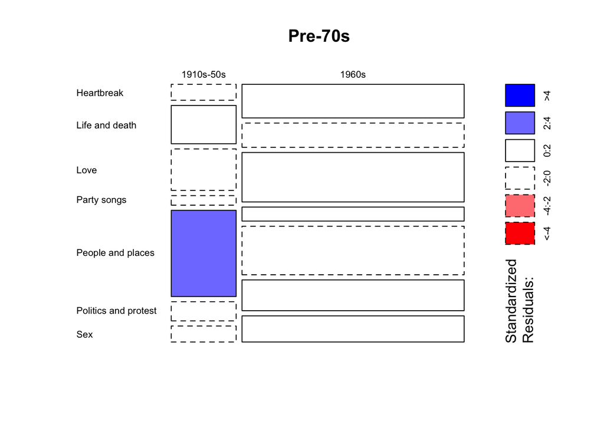

```r
#pre-70s plot
mosaicplot(table(pre70sSongs$decade, pre70sSongs$THEME), main = "Pre-70s",
    shade = TRUE, las = 1)
```

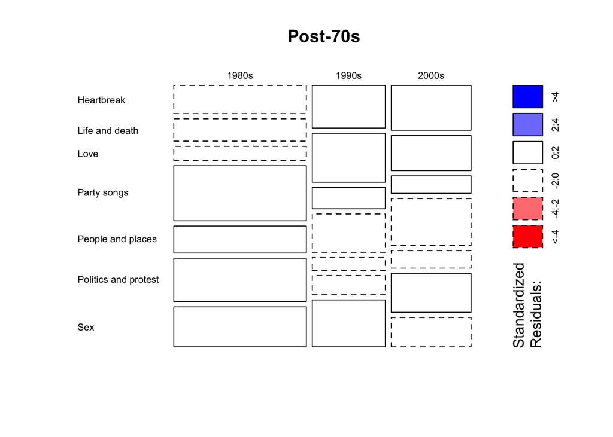

```r
#post-70s plot
mosaicplot(table(post70sSongs$decade, post70sSongs$THEME), main = "Post-70s",
    shade = TRUE, las = 1)
```

*From the first plot (using the pre-70s data), it appears that there are significantly more “people and places” songs than we would expect under the null hypothesis of independence, thereby suggesting that we should reject this null hypothesis (i.e., we would conclude that `decade` and `THEME` are not independent within the pre-70s data). Meanwhile, the second plot (using the post-70s data) does not indicate any substantially large Pearson residuals, thereby not providing any evidence to reject the null hypothesis of independence between `decade` and `THEME` for this dataset.*

7. (4pts) For the `pre70sSongs` and `post70sSongs` datasets in the previous part, run a chi-square test for independence between `decade` and `THEME`. (Don’t worry about any warnings you may get from these tests.) Interpret the results of each test in 1-2 sentences.

*Here are the chi-square tests for the pre-70s and post-70s datasets:*

```r
#pre-70s test
chisq.test(table(pre70sSongs$decade, pre70sSongs$THEME))
```

```
## Warning in chisq.test(table(pre70sSongs$decade, pre70sSongs$THEME)): Chi-squared
## approximation may be incorrect
```

```
##
##  Pearson's Chi-squared test
##
## data:  table(pre70sSongs$decade, pre70sSongs$THEME)
## X-squared = 13.225, df = 6, p-value = 0.0396
```

```r
#post-70s test
chisq.test(table(post70sSongs$decade, post70sSongs$THEME))
```

```
##
##  Pearson's Chi-squared test
##
## data:  table(post70sSongs$decade, post70sSongs$THEME)
## X-squared = 23.003, df = 12, p-value = 0.0277
```

*From both tests, we reject the null hypothesis that decade and theme are independent, thereby suggesting that these variables are dependent both before and after the 1970s.*

8. (4pts) Part F should have your interpretations for the mosaic plots, and Part G should have your interpretation for the chi-square tests. Do any of your interpretations contradict each other? If not, just say, “Nope, they don’t contradict each other.” If they do, write a 1-3 sentence explanation why the interpretations for the graphs and for the tests seem at odds with each other.

```r
residuals(chisq.test(table(post70sSongs$decade, post70sSongs$THEME)))
```

```
##
##         Heartbreak Life and death       Love Party songs People and places
##   1980s -1.2760811     -1.6797471 -0.6319976   0.8808838         1.2736435
##   1990s  0.6890028      1.9508354  0.7336139  -1.0009847        -1.1945178
##   2000s  0.9854574      0.2985223  0.1126808  -0.1776558        -0.4986951
##
##         Politics and protest        Sex
##   1980s            1.1461840  0.1782667
##   1990s           -1.9200130  0.8983469
##   2000s            0.3596486 -1.0891898
```

*The second and more important reason is that the chi-square test is a global test; i.e., it averages across the cells in the mosaic plot. From the mosaic plot, we can see that there is a general linear trend (the “higher than average” residuals are in the bottom left and top right), and once these are averaged across cells, that indicates large enough deviances from what we would expect under the null hypothesis to reject it. This is analogous to the phenomenon where all individual confidence intervals may have substantial overlap but a global F-test still rejects the null hypothesis that the group means are the same.*

# Problem 3: Trying to Find a Job with Many 2D Categorical Plots (25 Points)

At this point we’ve gone through many ways to display 2D categorical data. In this problem we will focus on the Twitter Airline Sentiment dataset, which we used in Lab3:

```r
library(tidyverse)
library(reshape2)

#  Read in data
airline_tweets <- read.csv("https://raw.githubusercontent.com/zjbranson/315Fall2021/master/Tweets.csv")

date_time <- colsplit(airline_tweets$tweet_created, " ", c("date", "time", "zone"))

#  Add start_date variable to airline_tweets, and a bunch of other variables
airline_tweets <- mutate(airline_tweets,
                    start_date = as.Date(date_time$date, format = "%Y-%m-%d"),
                    hour_of_day = as.integer(substr(date_time$time, 1, 2)),
                    am_or_pm = ifelse(hour_of_day < 12, "AM", "PM"),
                    day_of_week = weekdays(start_date),
                    weekend = ifelse(day_of_week %in% c("Saturday", "Sunday"),
                                     "Weekend", "Weekday"),
                    tweet_length = ifelse(nchar(as.character(text)) > 100, "Long", "Short"))
```

1. (12 points) Consider the following types of graphs:
- A side-by-side bar chart

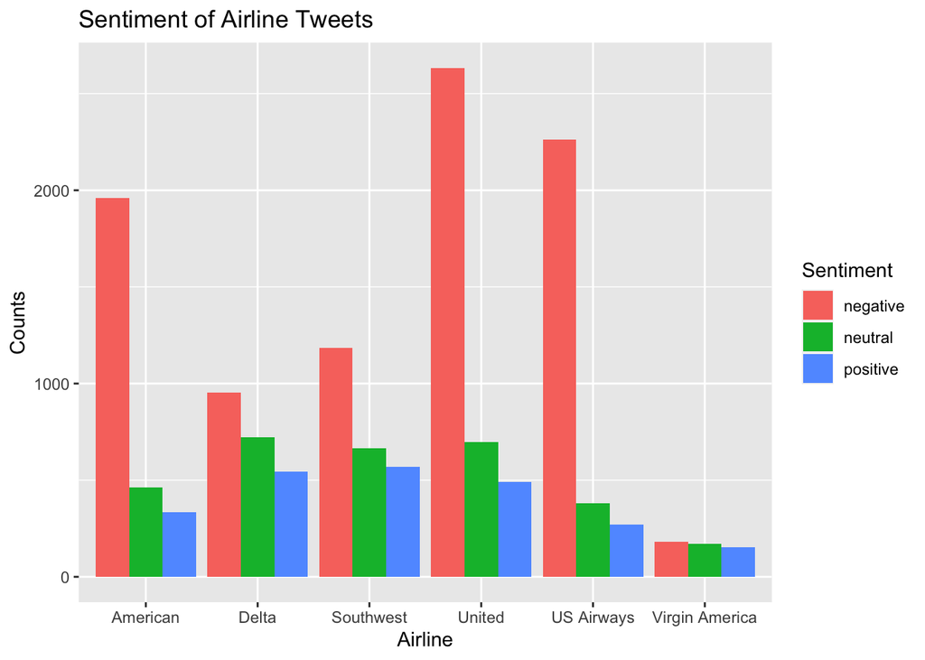

```r
# Side-by-side
ggplot(data = airline_tweets) +
  geom_bar(aes(x = airline, fill = airline_sentiment),
           position = "dodge") +
  labs(title = "Sentiment of Airline Tweets",
       x = "Airline",
       y = "Counts",
       fill = "Sentiment")
```

*For side-by-side bar charts, it’s fairly difficult to assess marginal distributions; however, it is easy to assess conditional distributions. In particular, by making `airline` correspond to the x-axis, we can easily see the conditional distribution of `airline_sentiment` given each `airline`. To assess the marginal distribution of `airline`, we can look at the total area of the bars corresponding to each airline - while this isn’t ideal, I decided to make the above choice so we could at least easily see the conditional distribution.*

- A stacked bar chart

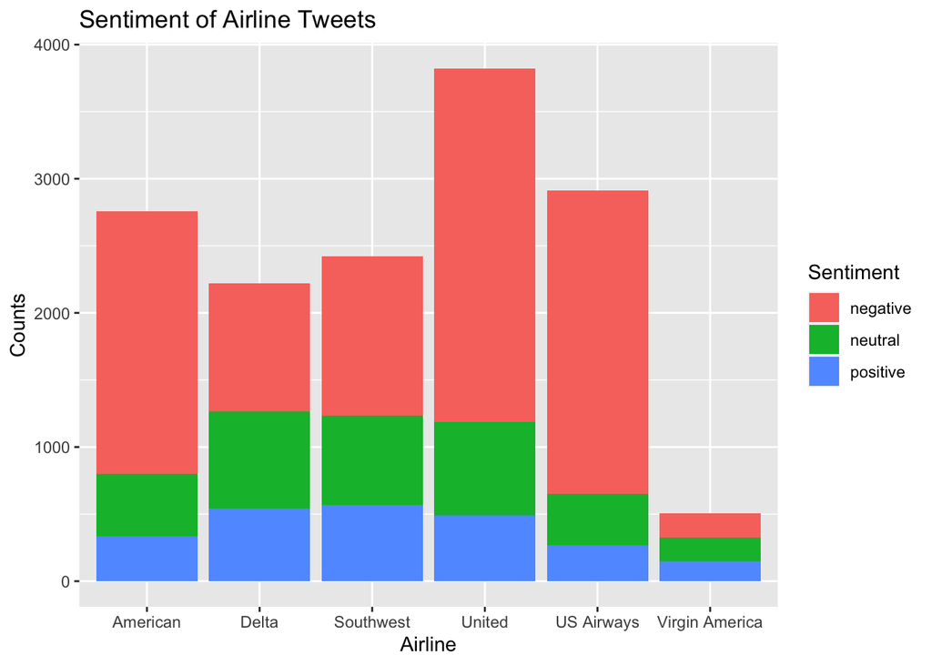

```r
#stacked bar chart
ggplot(data = airline_tweets) +
  geom_bar(aes(x = airline, fill = airline_sentiment)) +
  labs(title = "Sentiment of Airline Tweets",
       x = "Airline",
       y = "Counts",
       fill = "Sentiment")
```

*For stacked bar charts, it’s especially easy to see the marginal distribution of the variable that corresponds to the height of the bars - thus, we made `airline` correspond to the height of the bars. Meanwhile, within each bar, we can now easily assess the conditional distribution of `airline_sentiment` given `airline`.*

- A mosaic plot (colored by Pearson residuals)

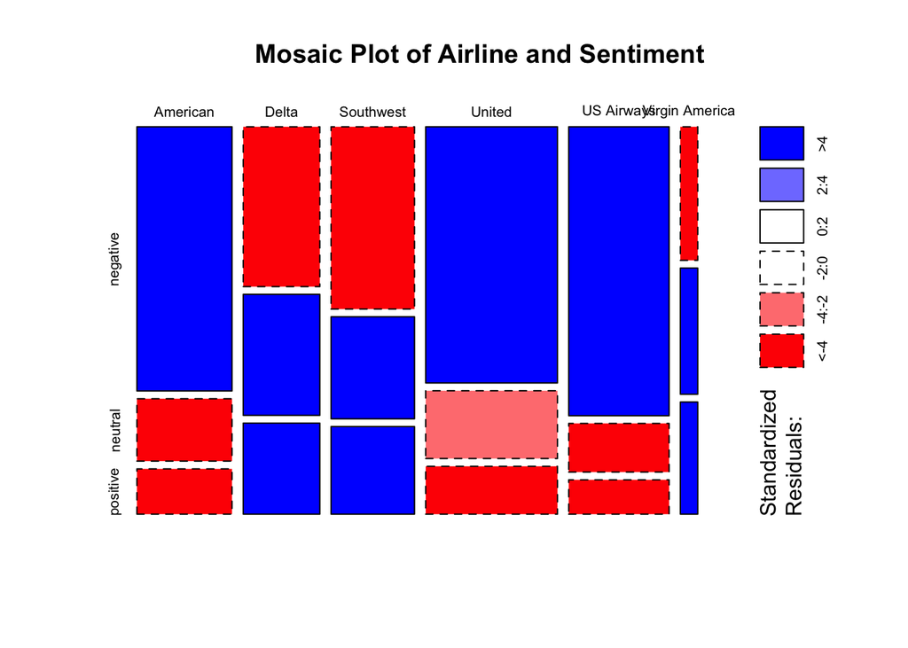

```r
#mosaic plot
mosaicplot(table(airline_tweets$airline, airline_tweets$airline_sentiment),
           shade = TRUE,
           main = "Mosaic Plot of Airline and Sentiment")
```

*For the mosaic plot, the width of the rectangles correspond to a marginal distribution, whereas the heights correspond to a conditional distribution. Thus, because the goal was to visualize the marginal distribution of `airline` (and the conditional distribution of `airline_sentiment` given `airline`), we ensured `airline` corresponded to the widths of the rectangles in the mosaic plot.*

- A facetted bar chart

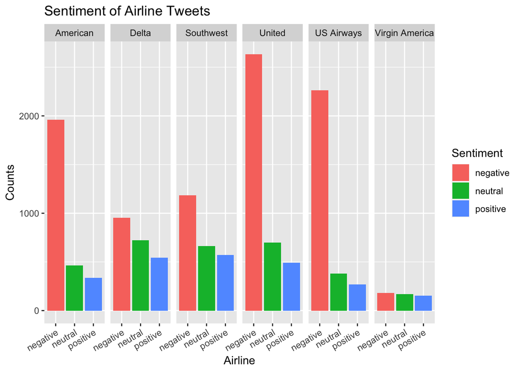

```r
#facetted bar chart
ggplot(data = airline_tweets) +
  geom_bar(aes(x = airline_sentiment, fill = airline_sentiment)) +
  facet_grid(~ airline) +
  labs(title = "Sentiment of Airline Tweets",
       x = "Airline",
       y = "Counts",
       fill = "Sentiment") +
  theme(axis.text.x = element_text(angle = 30, hjust = 1))
```

*Similar to side-by-side bar charts, it’s fairly difficult to assess marginal distributions for facetted bar charts; however, it is easy to assess conditional distributions. In particular, by making `airline` correspond to the facetting variable, we can easily see the conditional distribution of `airline_sentiment` given each `airline`. To assess the marginal distribution of `airline`, we can look at the total area of the bars in each facet - while this isn’t ideal, I decided to make the above choice so we could at least easily see the conditional distribution.*

For this part, make each type of graph such that you can best see the marginal distribution of the `airline` variable and the conditional distributions of `airline_sentiment` given each `airline` (within the limitations of each graph). Thus, for this part, you need to create four graphs; it’s okay if your graphs don’t have appropriate labels/title. Then, for each graph, write 1-2 sentences explaining why you made the choices you made for that graph.

**Hint**: For the last part of this question (the 1-2 sentences explanation), note that, for each graph, you’ll have to decide how to incorporate `airline` and how to incorporate `airline_sentiment`. Thus, in this part, you need to explain why you decided to make one part of the graph associated with `airline`, and another part of the graph associated with `airline_sentiment`.

2. (4 points) Now we will consider the relative strengths and weaknesses of the graphs you made in Part A. Answer the following questions:
- In which graph is it easiest to see the conditional distributions of `airline_sentiment` given each category of `airline`? Explain in 1-3 sentences.

*The faceted or side-by-side bar chart (which display essentially the same information) makes it easiest to see the conditional distribution of `airline_sentiment` given airline. For example, for any particular `airline`, it is quite easy to see what the distribution of sentiment is by comparing the three bars corresponding to that `airline`.*

- Which graph(s) provide the best balance of showing the marginal distribution of `airline` and the conditional distributions of `airline_sentiment` given `airline`? Explain in 1-3 sentences.

*Arguably, either the stacked bar chart, the side-by-side bar chart, or the faceted bar chart could strike the best balance between showing the marginal distribution of `airline` and the conditional distribution of `airline_sentiment` given `airline`. The stacked bar chart is the easiest of the three for looking at the marginal distribution, but makes it slightly harder to see the conditional distribution. (Not all of the stacked bars start at 0, thus forcing the reader to do some mental math.) The faceted and side-by-side bar charts make it easier to see the conditional distribution but harder to look at the marginal distribution, since the viewer has to manually add the heights of the individual conditional bars to find the marginal count.*

3. (9pts) Let’s say that you are on the job market as a data scientist, and you want to work for the airline that receives the largest proportion of positive tweets (to a statistically significant degree). Answer the following questions:
- Using your mosaic plot from Part A, which airlines appear to receive a larger proportion of positive tweets to a statistically significant degree, compared to what we would expect if `airline` didn’t have any relationship with `airline_sentiment`? State the airlines, and then explain how you arrived at your answer in 1-2 sentences.

*Looking back at the mosaic plot in Part A, we can see that Delta, Southwest, and Virgin America appear to receive a larger proportion of positive tweets than what we would expect under independence of `airline` and `airline_sentiment` (because the rectangles corresponding to positive sentiment for those airlines are blue, thereby denoting more positive tweets than what we would expect under independence).*

- Using a **new** mosaic plot, answer the following: *Among the airlines you listed in the previous part*, do any of the airlines appear to receive a larger proportion of positive tweets (compared to the other airlines you listed) to a statistically significant degree? If so, which one(s)? Explain your answer in 1-2 sentences, and be sure to include your new mosaic plot in your answer.

**Hint**: For the second part, you’ll likely need to use the `subset()` function to get a subset of tweets belonging to certain airlines. For example, the following code grabs tweets for American or Delta airlines:

```r
example = subset(airline_tweets, airline == "American" | airline == "Delta")
table(example$airline)
```

```
##
## American    Delta
##     2759     2222
```

This code is just provided as an example of how to use the `subset()` function within the context of this question; I’m not saying that you have to use the above code in your solution to this problem.

*In the previous question, we stated that Delta, Southwest, and Virgin America appear to receive a larger proportion of positive tweets. Thus, now we want to compare the amount of positive tweets for these airlines specifically. Thus, it will be helpful to create a subset of the data that only contains these airlines:*

```r
airline_tweets_subset = subset(airline_tweets, airline == "Delta" | airline == "Southwest" | airline == "Virgin America")
```

*Then, we can create a mosaic plot for this subset:*

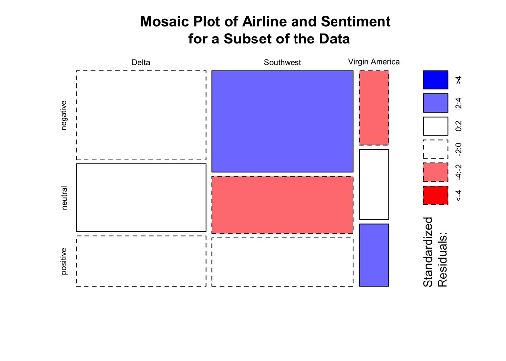

```r
mosaicplot(table(airline_tweets_subset$airline, airline_tweets_subset$airline_sentiment),
           shade = TRUE,
           main = "Mosaic Plot of Airline and Sentiment \n for a Subset of the Data")
```

*From this plot, it appears that Virgin America receives a larger proportion of positive tweets than what we would expect if `airline` and `airline_sentiment` were independent for these three airlines; because there is blue shading for the rectangle corresponding to positive tweets to Virgin America (denoting Pearson residuals greater than 2), we would conclude that this is a statistically significant difference.*

*(Note: This is not an endorsemenet of Virgin America. Also, it’s important to remember that this question was about the proportion of positive tweets. Looking back at one of the plots in Part A - such as the facetted bar chart - we can see that, while Virgin America receives a larger proportion of positive tweets compared to other airlines, it still receives nominally more negative tweets than neutral or positive tweets (which is the case for all airlines). Thus, it seems like, regardless of what airline you work for, you would have to sift through a lot of negative tweets!)*